# Visualize intrasepecific trait variation measurements

Chieh

2023-05-22

This document aims to show trait variation within a seagrass species. The raw data were obtained from 12 distinct locations in Queensland, Australia. The measurements primarily took place within a controlled wet laboratory environment, employing appropriate scientific instruments. However, a subset of finer-scale measurements, typically measuring less than 5 mm, were conducted digitally using the ImageJ software on a computer

Read trait measured data and rearanging it to plotting format.

```r
trait_dat <- read.csv("../Raw_data.csv", header = TRUE)

trait_dat %>%
  mutate(Belowground_dry_mass1 = as.numeric(Belowground_dry_mass1)) %>%
  select(!ends_with("photo.") & !contains("note") &
          !Pack &
          !Aboveground_dry_mass3 &
          !Belowground_dry_mass3 &
          !Flower_seed) %>%
  pivot_longer(cols = Canopyheight_1:Internodelength_10,
               names_to = c(".value", "trials"),
               names_sep = "_" ) -> trait_long_dat
head(trait_long_dat)
```

```
## # A tibble: 6 × 22
##   SampleID      Location   Latitude Longitude Replicate Date       Species abb
##   <chr>         <chr>         <dbl>     <dbl>     <int> <chr>      <chr>   <chr>
## 1 PAL1_28082022 Pallarenda    -19.2      147.         1 28/08/2022 Holudu… HUN
## 2 PAL1_28082022 Pallarenda    -19.2      147.         1 28/08/2022 Holudu… HUN
## 3 PAL1_28082022 Pallarenda    -19.2      147.         1 28/08/2022 Holudu… HUN
## 4 PAL1_28082022 Pallarenda    -19.2      147.         1 28/08/2022 Holudu… HUN
## 5 PAL1_28082022 Pallarenda    -19.2      147.         1 28/08/2022 Holudu… HUN
## 6 PAL1_28082022 Pallarenda    -19.2      147.         1 28/08/2022 Holudu… HUN
## # ℹ 14 more variables: Shoot_number <int>, Aboveground_wet_mass <dbl>,
## #   Aboveground_dry_mass1 <dbl>, Aboveground_dry_mass2 <dbl>,
## #   Belowground_wet_mass <dbl>, Belowground_dry_mass1 <dbl>,
## #   Belowground_dry_mass2 <dbl>, trials <chr>, Canopyheight <dbl>,
## #   Leaflength <dbl>, Leafwidth <dbl>, Rootlength <dbl>, Rhizomediameter <dbl>,
## #   Internodelength <dbl>
```

plot the potential intraspecific trait variation of each species.

Holudule uninervis traits

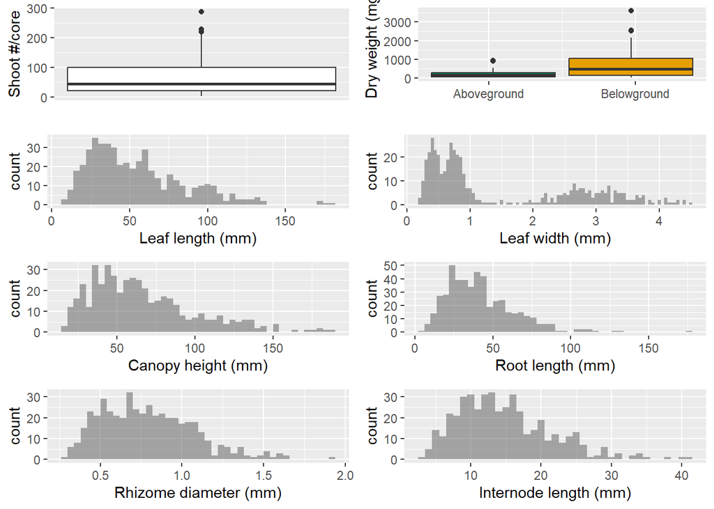

```r
trait_plot(HU, 4, 0.05, 4, 4, 0.04, 1)
```

Halophila ovalis traits

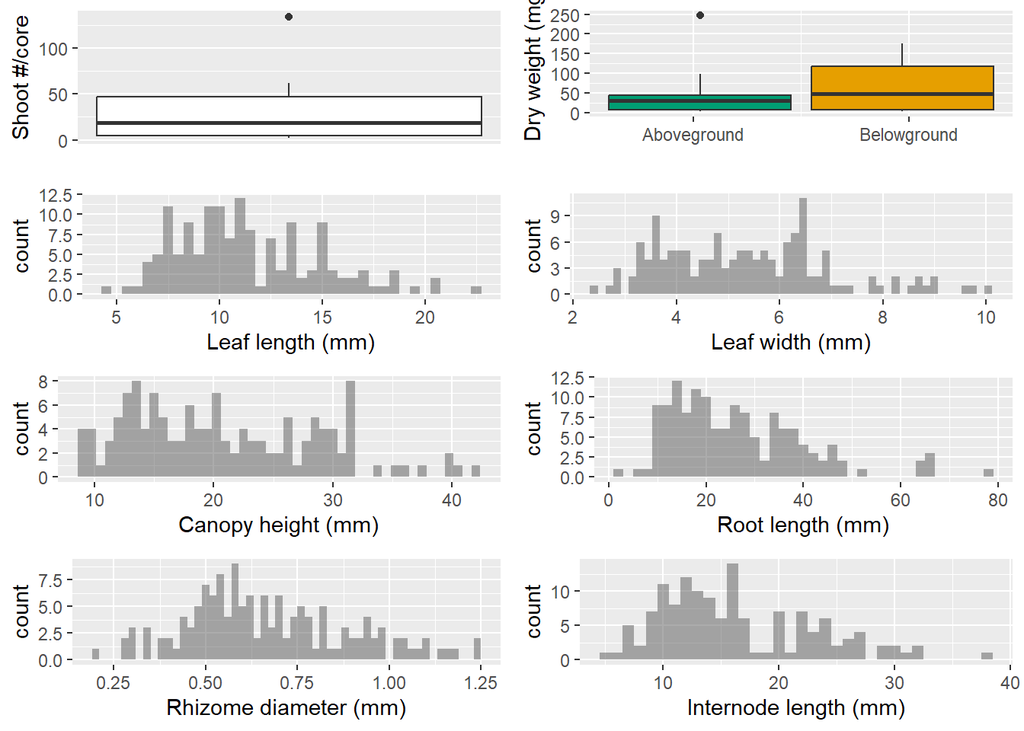

```r
trait_plot(HO, 0.5, 0.15, 0.75, 2, 0.02, 1)
```

Zostera muelleri subsp. Capricorni traits

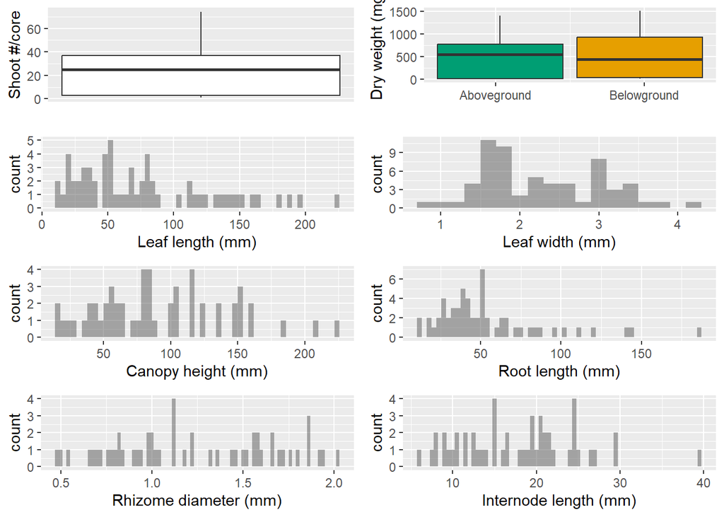

```r
trait_plot(ZC, 4, 0.2, 4, 3, 0.02, 0.5)
```

Cymodocea serrulata traits

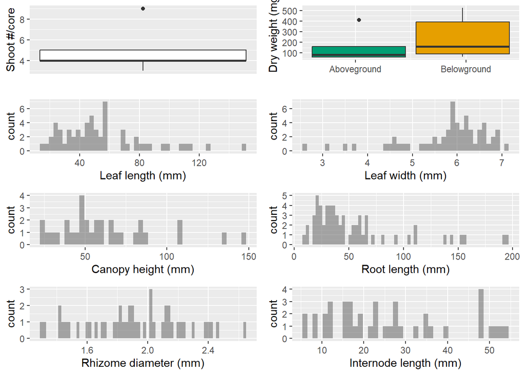

```r
trait_plot(CS, 3, 0.1, 3, 3, 0.02, 1.2)
```

Halophila spinulosa traits

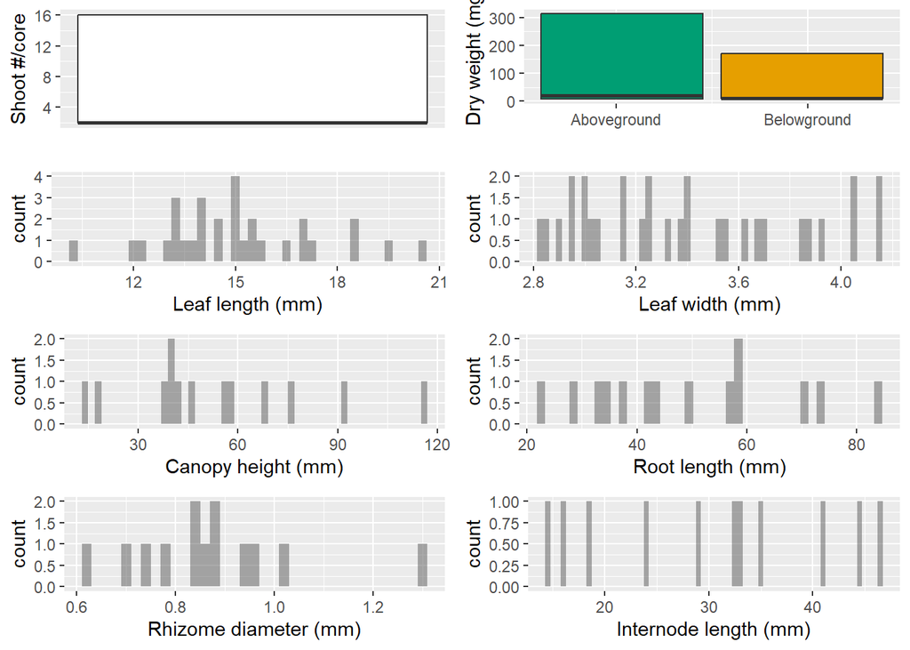

```r
trait_plot(HS, 0.25, 0.025, 2, 1.5, 0.02, 0.5)
```

Thalassia hemprichii traits

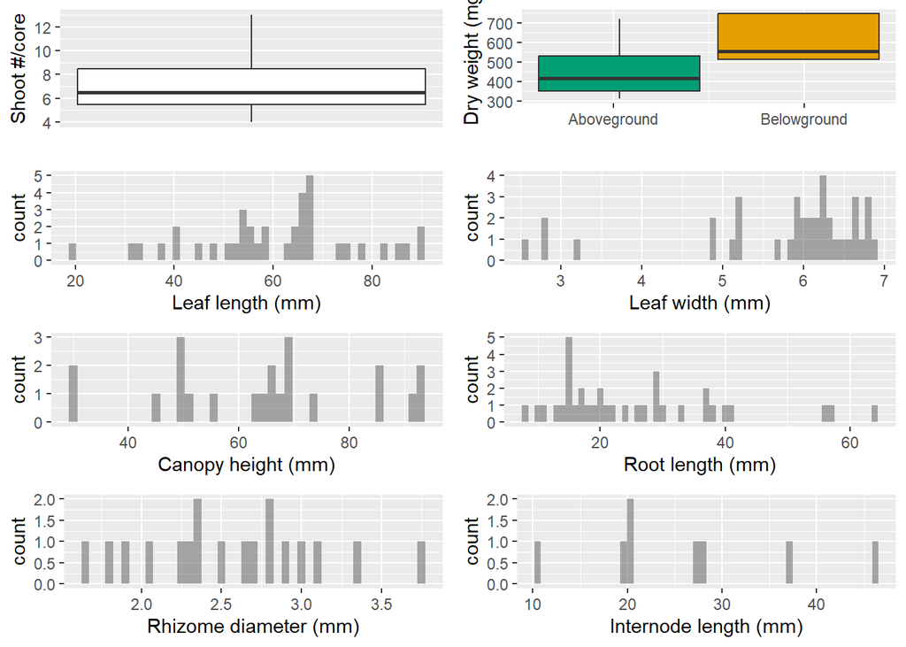

```r
trait_plot(TH, 1.5, 0.08, 1.5, 1, 0.05, 0.7)
```

Trait of narrow versus wide form of Haludule uninervis

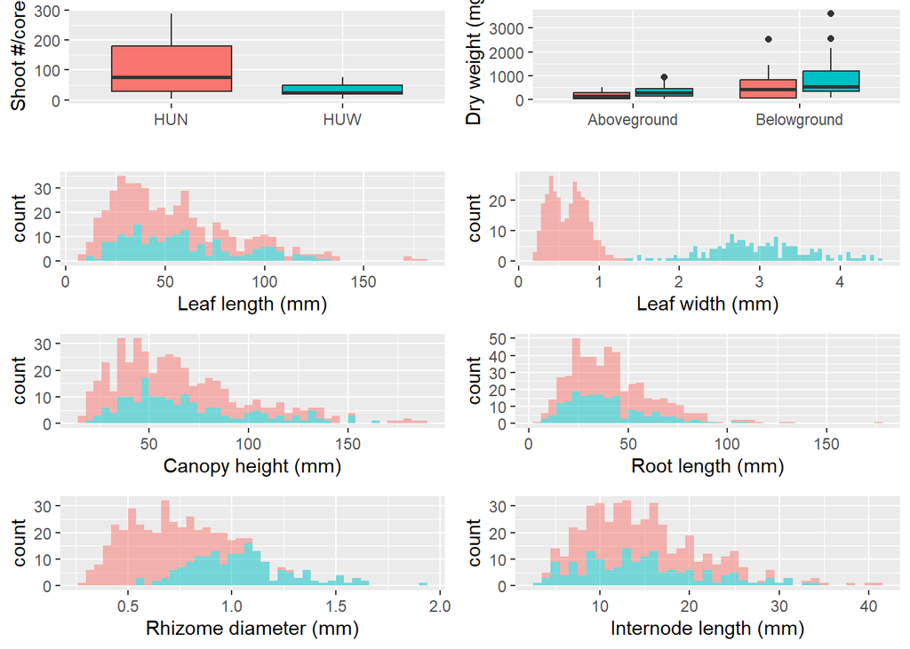

The clear difference is at Leaf width. The rhizome diameter is also quite distinct for two form but with a overlap zone. Leaf width indicates there might be three groups instead of two. Location specific leaf width of HUN and HUW. These graph indicate potential grouops in HU.

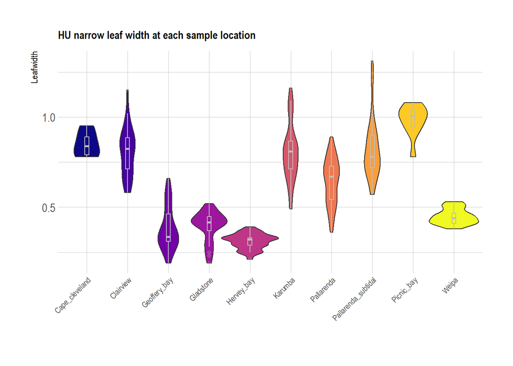

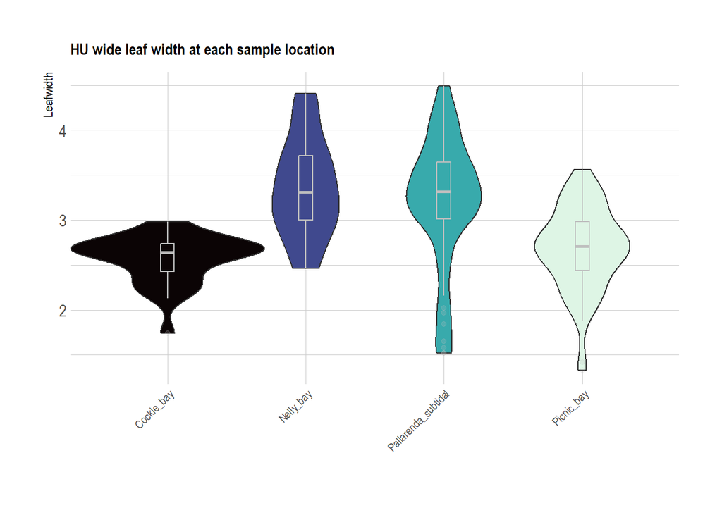

HO leaf surface area distribution.

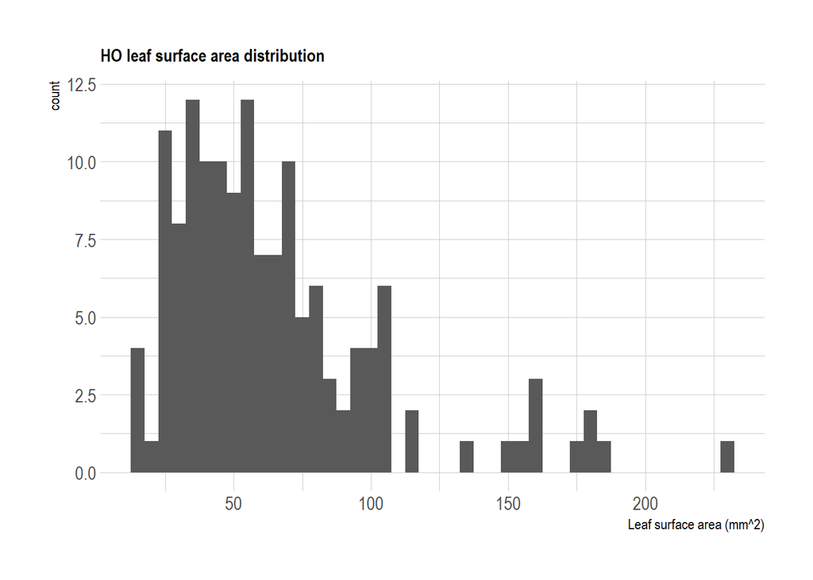

Tried to see is there any distinct groups of leaf size of HO, because I felt there a big leaf individuals and small leaf ones. However, it seems to be a continous distibution.